# Regresión Lineal Simple

Juan Barriola, Azul Villanueva y Franco Mastelli

27 de Agosto de 2022

**Encuesta de Sueldos en el sector IT**

## Planteo del problema

Vamos a trabajar con un dataset de la encuesta de sueldos en el sector de tecnología en Argentina realizada por SysArmy para el segundo semestre de 2022.

El objetivo es crear un modelo lineal simple para explicar el sueldo bruto de los Data Analysts, Data Scientists y Data Engineers en Argentina.

La idea subyacente de cómo se puede explicar el salario bruto es:

$salarioBruto = \beta_0 +\beta_1X+\epsilon$

Entonces, vamos a trabajar el set de datos con esta idea de modelo presente.

```r
# Carga de librerías
library(tidyverse)
library(corrr)
library(knitr)
library(kableExtra)
library(GGally)
```

## Preparación de Datos

Comenzamos leyendo los datos y viendo su estructura.

```r
encuesta <- read_csv("../Fuentes/regresion_simple/encuesta_sueldos_sysarmy_2s2022.csv")
encuesta %>%
  glimpse()
```

```
## Rows: 5,358
## Columns: 44
## $ estoy_trabajando_en                                                                  <chr> …
## $ donde_estas_trabajando                                                               <chr> …
## $ dedicacion                                                                           <chr> …
## $ tipo_de_contrato                                                                     <chr> …
## $ ultimo_salario_mensual_o_retiro_bruto_en_tu_moneda_local                             <chr> …
## $ ultimo_salario_mensual_o_retiro_neto_en_tu_moneda_local                              <chr> …
## $ pagos_en_dolares                                                                     <chr> …
## $ si_tu_sueldo_esta_dolarizado_cual_fue_el_ultimo_valor_del_dolar_que_tomaron          <chr> …
## $ pagos_en_criptomonedas                                                               <chr> …
## $ que_porcentaje_o_monto_recibis_en_criptomonedas                                      <chr> …
## $ recibis_algun_tipo_de_bono                                                           <chr> …
## $ a_que_esta_atado_el_bono                                                             <chr> …
## $ tuviste_actualizaciones_de_tus_ingresos_laborales_durante_2022                       <chr> …
```

[output cut: 31 more lines]

Existen 5358 respuestas de 44 preguntas distintas. Nos vamos a quedar con las respuestas de las personas que trabajan como Data Analysts, Data Scientists y Data Engineers. Entonces, construimos un subconjunto de los datos que incluya esos perfiles.

```r
# Filtro de los perfiles de interés
encuesta_ds = encuesta %>%
                filter(trabajo_de %in% c("Data Scientist", "BI Analyst / Data Analyst", "Data Engineer"))
# Función para describir las dimensiones
dim_desc(encuesta_ds)
```

```
## [1] "[379 x 44]"
```

Existen 379 respuestas (observaciones) que cumplen con este criterio.

## Análisis exploratorios

Realicemos algunos análisis exploratorios para conocer mejor el dataset.

### Valores únicos y faltantes

Una de las primeras características para revisar en un dataset es la cantidad de valores únicos y porcentaje de valores faltantes que tiene cada variable.

```r
tabla_exploratorios =  encuesta_ds %>%
                                      gather(.,
                                            key = "variables",
                                            value = "valores") %>% # agrupamos por las variables del set
                                      group_by(variables) %>%
                                      summarise(valores_unicos = n_distinct(valores),
                                      porcentaje_faltantes = sum(is.na(valores))/nrow(encuesta_ds)*100) %>%
                                      arrange(desc(porcentaje_faltantes), valores_unicos) # ordenamos por porcentaje de faltantes y valores unicos
tabla_exploratorios
```

| variables | valores_unicos | porcentaje_faltantes |
| --- | --- | --- |
| pagos_en_criptomonedas | 3 | 96.569921 |
| si_participaste_de_un_boot_campque_carrera_estudiaste | 21 | 93.667546 |
| participaste_de_algun_boot_camp | 25 | 86.543536 |
| si_tu_sueldo_esta_dolarizado_cual_fue_el_ultimo_valor_del_dolar_que_tomaron | 44 | 86.015831 |
| que_porcentaje_o_monto_recibis_en_criptomonedas | 12 | 85.751979 |
| pagos_en_dolares | 4 | 75.461741 |
| porcentajebruto_o_neto | 4 | 68.337731 |
| tenes_guardias | 4 | 68.337731 |
| cuanto_cobras_por_guardia | 6 | 68.337731 |
| universidad | 64 | 44.854881 |

[output cut: 34 more lines]

Vemos que una serie de variables presentan un alto porcentaje de faltantes. Podemos observar aquellas variables que tienen faltantes en un gráfico.

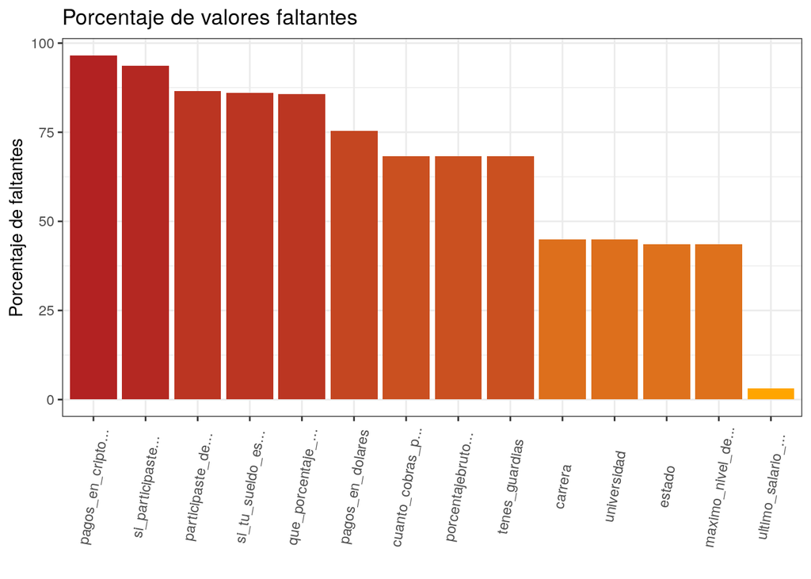

```r
tabla_exploratorios %>% filter(porcentaje_faltantes>0) %>%
ggplot(., aes(x=reorder(variables, -porcentaje_faltantes), y=porcentaje_faltantes, fill=porcentaje_faltantes)) +
  geom_bar(stat = "identity") +
  scale_fill_gradient(high = "firebrick", low = "orange") +
  scale_x_discrete(label = function(x) stringr::str_trunc(x, 18)) +
  theme_bw() +
  theme(axis.text.x = element_text(angle=80, vjust=0.5), legend.position = "none") +
  labs(title='Porcentaje de valores faltantes', y='Porcentaje de faltantes', x='')
```

La variable a explicar: **salario bruto** no presenta valores faltantes.

### Selección de variables

Seleccionamos las variables que nos interesan. En este caso incluiremos la variable a predecir **salario bruto** y 7 variables más.

```r
encuesta_ds_relevantes = encuesta_ds %>%
                              # Seleccionamos las variables de interés
                              select(tengo_edad, anos_de_experiencia, antigüedad_en_la_empresa_actual, tiempo_en_el_puesto_actual,
                                     trabajo_de, ultimo_salario_mensual_o_retiro_bruto_en_tu_moneda_local,
                                     ultimo_salario_mensual_o_retiro_neto_en_tu_moneda_local, sueldo_dolarizado) %>%
                              #Renombramos algunas variables
                              rename(edad = tengo_edad,
                                     perfil = trabajo_de,
                                     anos_en_el_puesto_actual = tiempo_en_el_puesto_actual,
                                     anos_en_la_empresa_actual = antigüedad_en_la_empresa_actual,
                                     salario_bruto = ultimo_salario_mensual_o_retiro_bruto_en_tu_moneda_local,
                                     salario_neto = ultimo_salario_mensual_o_retiro_neto_en_tu_moneda_local) %>%
                              # Forzamos a que estas variables tomen un valor numerico
                              mutate(edad = as.numeric(edad),
                                     salario_bruto = as.numeric(salario_bruto),
                                     salario_neto = as.numeric(salario_neto)) %>%
                              drop_na(edad, salario_bruto, anos_de_experiencia, anos_en_la_empresa_actual)
```

### GGPairs I

Realizamos un primer análisis descriptivo de nuestro dataset de columnas relevantes. Para ello utilizamos la función `ggpairs` sobre las variables numéricas con una apertura por la variable de perfil.

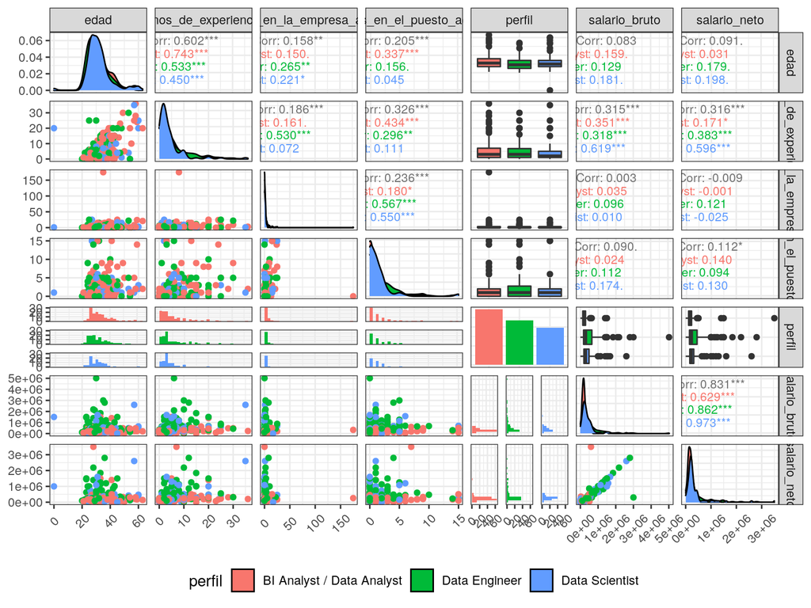

```r
encuesta_ds_relevantes %>% select(-sueldo_dolarizado) %>%
  ggpairs(aes(color=perfil), upper = list(continuous = wrap("cor", size = 3, hjust=0.8, alignPercent=0.15)), legend = 25) +
  theme_bw() +
  theme(axis.text.x = element_text(angle=45, vjust=0.5), legend.position = "bottom")
```

Respecto de nuestra variable a predecir, el **salario bruto**, observamos:

- Todas las variables, excepto el salario neto y en menor medida los años de experiencia, presentan una correlación muy baja con esta variable.
- En los gráficos de dispersión con las variables de edad, salario neto, años de experiencia y años en el puesto se observan varios puntos que parecen ser outliers.

Parece existir:

- Inconsistencias en la información de salario neto y salario bruto.
- Algunas observaciones con una relación “extraña” entre la edad y los años de experiencia.

## Limpieza de datos

En base a nuestro análisis de valores faltantes y exploratorios procedemos a realizar la limpieza de nuestro dataset

### Delimitar el modelo: Sueldo dolarizado

Eliminamos aquellas observaciones con el sueldo dolarizado para no incluir variaciones vinculadas al tipo de cambio en nuestro set de datos.

```r
n_dolarizados <- encuesta_ds_relevantes %>%
  filter(sueldo_dolarizado==1) %>% # Observaciones con el sueldo dolarizado
  nrow()
```

Este filtro elimina 92 observaciones.

### Datos inconsistentes

Comencemos analizando aquellos registros que presentan datos que no son consistentes.

#### Edad vs. Años de experiencia

Como ya mencionamos, parecen existir algunos registros con una relación “extraña” entre la edad y los años de experiencia. Realizamos el gráfico de dispersión entre estas dos variables para analizar mejor su relación.

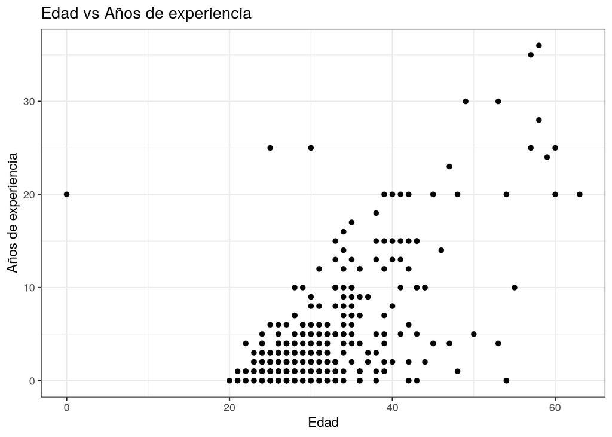

```r
ggplot(encuesta_ds_relevantes, aes(x = edad, y = anos_de_experiencia)) +
        geom_point() +
        theme_bw() +
        labs(x="Edad", y="Años de experiencia", title = "Edad vs Años de experiencia")
```

Pueden existir dos situaciones problemáticas:

- los años de experiencia superan a la edad
- sabiendo que la edad mínima para trabajar en Argentina es 14 años, podemos revisar en que registros la diferencia entre la edad y los años de experiencia es menor a dicho umbral

Veamos cuantos registros eliminamos con estos filtros.

```r
edad_laboral_minima = 14
df_errores_edad <- encuesta_ds_relevantes %>%
  filter(edad-anos_de_experiencia<=edad_laboral_minima) %>% # filtro de los problemas con la edad
  select(edad, anos_de_experiencia)
df_errores_edad
```

| edad | anos_de_experiencia |
| --- | --- |
| 30 | 25 |
| 0 | 20 |
| 25 | 25 |

Son 3 registros en los cuales hay casos de ambas problemáticas.

#### Salario neto superior al bruto

Pueden existir registros en los cuales el salario neto supere al bruto, lo cual es una inconsistencia en los datos.

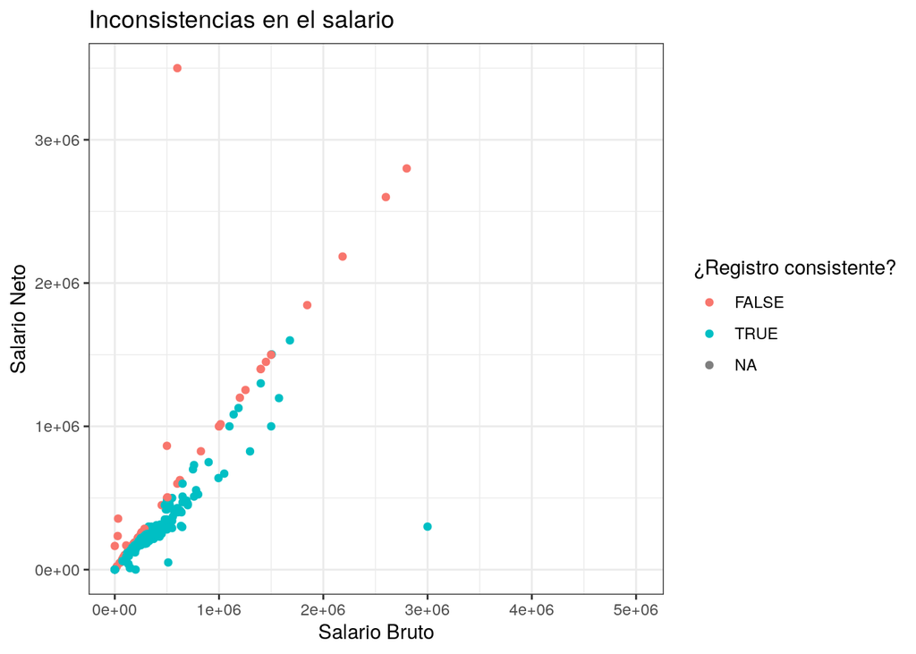

```r
ggplot(encuesta_ds_relevantes, aes(x=salario_bruto, y=salario_neto, color = salario_neto<salario_bruto)) +
        geom_point() +
        theme_bw() +
        labs(title = "Inconsistencias en el salario", x="Salario Bruto", y="Salario Neto", color="¿Registro consistente?")
```

En el gráfico observamos que existen algunos registros con datos inconsistentes.

```r
df_errores_sueldos <- encuesta_ds_relevantes %>%
  filter(salario_bruto<salario_neto) %>%
  select(salario_bruto, salario_neto)

df_errores_sueldos
```

| salario_bruto | salario_neto |
| --- | --- |
| 207.58 | 165000 |
| 109769.00 | 168900 |
| 32000.00 | 356000 |
| 600000.00 | 3500000 |
| 257326.00 | 261381 |
| 27900.00 | 234500 |
| 20000.00 | 23000 |
| 95000.00 | 102000 |
| 178000.00 | 180000 |
| 500000.00 | 864000 |

[output cut: 1 more lines]

Al igual que antes podríamos tratar de imputar un valor para nuestra variable a predecir o eliminarlos. Al tratarse de 11 registros los vamos a eliminar.

#### Conjunto de filtros

Realizamos todos los filtros que fuimos describiendo en las subsecciones pasadas para quedarnos con un conjunto de datos consistentes según los criterios que definimos previamente.

```r
# Conjunto de filtros
encuesta_ds_filtrada = encuesta_ds_relevantes %>%
                          filter(sueldo_dolarizado==0, #Eliminamos los sueldos dolarizados
                                 edad-anos_de_experiencia>=edad_laboral_minima, # Eliminamos registros inconsistentes con la edad laboral
                                 salario_bruto>salario_neto) %>%  # Inconsistencia en los sueldos
                          select(-sueldo_dolarizado) # Eliminamos la columna de sueldo dolarizado
```

### GGPairs II

Habiendo aplicado los filtros volvemos a realizar el análisis exploratorio con ggpairs.

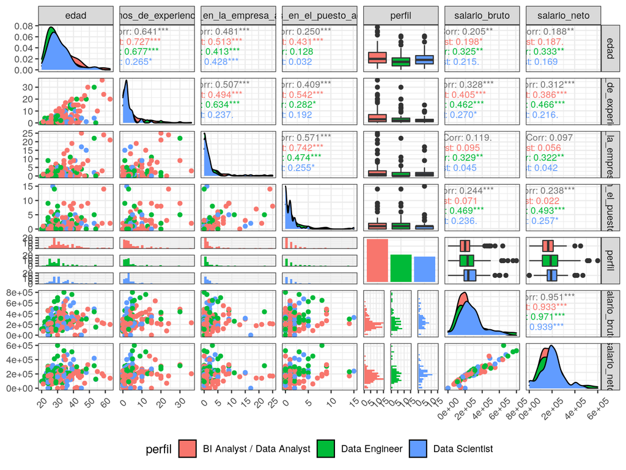

```r
encuesta_ds_filtrada %>%
  ggpairs(aes(color=perfil), upper = list(continuous = wrap("cor", size = 3, hjust=0.8, alignPercent=0.15)), legend = 25) +
  theme_bw() +
  theme(axis.text.x = element_text(angle=45, vjust=0.5), legend.position = "bottom")
```

Respecto de nuestra variable a predecir, el **salario bruto**, observamos:

- Observamos que todas las variables incrementaron su correlación con esta variable.
- Sigue siendo bajo el coeficiente de los años de experiencia en la empresa actual, aunque para el grupo de *Data Engineer* presentan un correlación positiva moderada.
- Siguen existiendo algunas observaciones atípicas

Para profundizar un poco más en este análisis podemos observar los valores de la correlación de Spearman (robusta a outliers) y compararlos con los obtenidos en la matriz anterior.

```r
encuesta_ds_filtrada %>%
  select_if(is.numeric) %>% # selecciona las variables numericas
  correlate(method = 'spearman') %>% # convierte la matriz de corr en dataframe
  shave() %>% # solo muestra información debajo de la diagonal principal
  fashion(decimals = 3) # acomoda los datos en forma tidy (por ej. redondeo de decimales)
```

| term | edad | anos_de_experiencia | anos_en_la_empresa_actual | anos_en_el_puesto_actual | salario_bruto | salario_neto |
| --- | --- | --- | --- | --- | --- | --- |
| edad |  |  |  |  |  |  |
| anos_de_experiencia | .501 |  |  |  |  |  |
| anos_en_la_empresa_actual | .289 | .506 |  |  |  |  |
| anos_en_el_puesto_actual | .232 | .515 | .778 |  |  |  |
| salario_bruto | .306 | .526 | .263 | .245 |  |  |
| salario_neto | .273 | .492 | .247 | .236 | .974 |  |

Existen varios pares de variables que presentan cambios entre la correlación de Pearson y la de Spearman, por ejemplo la correlación entre el salario bruto y años de experiencia.

### Outliers Univariados

Analicemos la existencia de outliers del salario bruto mensual.

#### Boxplot

Comenzamos graficando el boxplot de la variable.

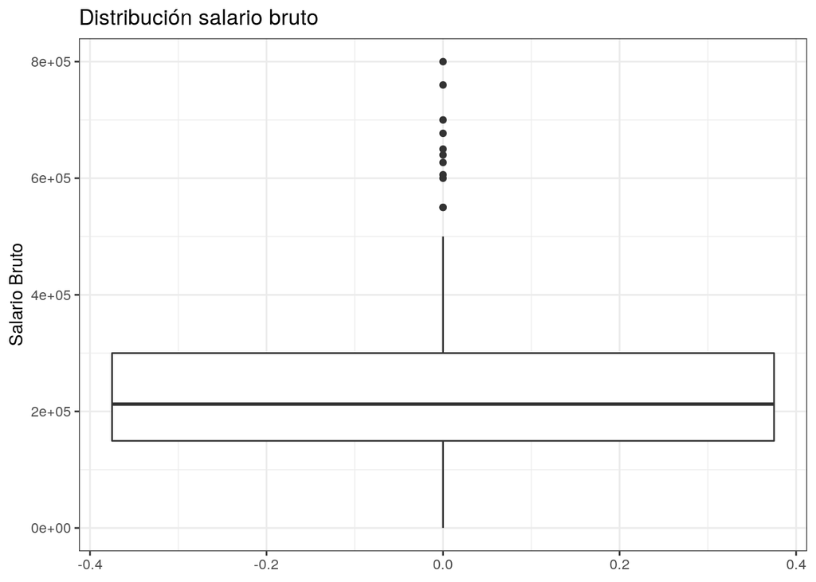

```r
ggplot(encuesta_ds_filtrada, aes(y=salario_bruto)) +
  geom_boxplot() +
  theme_bw() +
  labs(title="Distribución salario bruto", y="Salario Bruto")
```

El gráfico nos indica que existen outliers “superiores” de acuerdo al criterio del boxplot.

Recordemos que con el criterio del rango intercuartil (boxplot):

Un outlier “superior” se define como aquel valor *q* el cual cumple:

$q> Q_3 + 1.5 \cdot IQR$

UN outlier “inferior” se define como aquel valor *q* el cual cumple:

$q< Q_1 - 1.5 \cdot IQR$

Siendo $Q_1$: primer cuartil, $Q_3$: tercer cuartil e $IQR=Q_3 - Q_1$: rango intercuartil

Construimos el límite superior e inferior para identificar y filtrar outliers

```r
limite_superior_outliers = IQR(encuesta_ds_filtrada$salario_bruto) * 1.5 + quantile(encuesta_ds_filtrada$salario_bruto, 0.75)[[1]]
limite_superior_outliers
```

```
## [1] 525831.4
```

Veamos cuántos registros superan dicho límite

```r
outliers_sueldo <- encuesta_ds_filtrada %>% filter(salario_bruto>limite_superior_outliers)
outliers_sueldo
```

| edad | anos_de_experiencia | anos_en_la_empresa_actual | anos_en_el_puesto_actual | perfil | salario_bruto | salario_neto |
| --- | --- | --- | --- | --- | --- | --- |
| 39 | 12 | 1 | 3 | Data Engineer | 760000 | 510000 |
| 34 | 5 | 3 | 3 | Data Scientist | 600000 | 400000 |
| 36 | 4 | 4 | 4 | Data Scientist | 677000 | 470000 |
| 28 | 5 | 5 | 5 | Data Engineer | 627000 | 412081 |
| 30 | 9 | 6 | 6 | Data Engineer | 700000 | 450000 |
| 40 | 2 | 1 | 1 | Data Scientist | 606000 | 402000 |
| 35 | 17 | 2 | 1 | BI Analyst / Data Analyst | 640000 | 400000 |
| 34 | 5 | 0 | 0 | Data Engineer | 800000 | 525000 |
| 34 | 7 | 7 | 2 | BI Analyst / Data Analyst | 550000 | 290000 |
| 38 | 5 | 2 | 1 | Data Scientist | 550000 | 340000 |

[output cut: 1 more lines]

Son 11 registros en total. Todos parecen ser outliers “genuinos”.

Construimos el límite inferior:

```r
limite_inferior_outliers = quantile(encuesta_ds_filtrada$salario_neto, 0.25)[[1]] - IQR(encuesta_ds_filtrada$salario_neto) * 1.5
limite_inferior_outliers
```

```
## [1] -46323.38
```

El límite inferior es negativo, por lo tanto, no tiene sentido filtrar por dicho valor.

Entonces, eliminamos sólo los outliers superiores según este criterio.

**ACLARACION**: en este caso eliminamos los outliers con una finalidad pedagógica. Existen herramientas que se verán en el curso que permiten trabajar con outliers sin eliminarlos.

```r
encuesta_ds_sin_outliers = encuesta_ds_filtrada %>% filter(salario_bruto<=limite_superior_outliers)
```

#### Percentiles

Dada la distribución de los datos deberíamos estudiar qué sucede en la cola izquierda de la distribución. Para ello, creamos una función que nos permita observar los percentiles de una variable en una tabla.

```r
# Funcion para crear una tabla con los percentiles deseados de la variable
crear_tabla_percentiles <- function(vector, q = c(0.25, 0.5, 0.75)) {
  tibble("{{ vector }}" := quantile(vector, q), "{{ vector }}_q" := q)
}

# Creamos el vector del salario
salario_bruto_vec = encuesta_ds_sin_outliers$salario_bruto

# Creamos la tabla de percentiles en intervalos de a 5%
percentiles_salario_bruto = crear_tabla_percentiles(salario_bruto_vec, c(seq(0,.1,0.01)))
percentiles_salario_bruto
```

| salario_bruto_vec | salario_bruto_vec_q |
| --- | --- |
| 130.0 | 0.00 |
| 241.6 | 0.01 |
| 376.0 | 0.02 |
| 73040.0 | 0.03 |
| 80000.0 | 0.04 |
| 85800.0 | 0.05 |
| 89680.0 | 0.06 |
| 95000.0 | 0.07 |
| 100000.0 | 0.08 |
| 100000.0 | 0.09 |

[output cut: 1 more lines]

Vemos que hasta el percentil 2 los valores son anormalmente bajos pero no podían ser filtrados por el criterio anterior. Un valor apropiado para filtrar valores bajos parece ser el del percentil 3. Por lo que definimos este valor como límite inferior.

```r
# Seleccionamos el valor del salario bruto del percentil 2
limite_inferior_percentil = percentiles_salario_bruto %>%
                                filter(salario_bruto_vec_q==0.03) %>%
                                select(salario_bruto_vec) %>%
                                as.numeric()
```

```r
encuesta_ds_final = encuesta_ds_sin_outliers %>%
  filter(salario_bruto >= limite_inferior_percentil)
```

### GGPairs III

Habiendo eliminado los outliers univariados de la variable respuesta realizamos un último análisis exploratorio con ggpairs.

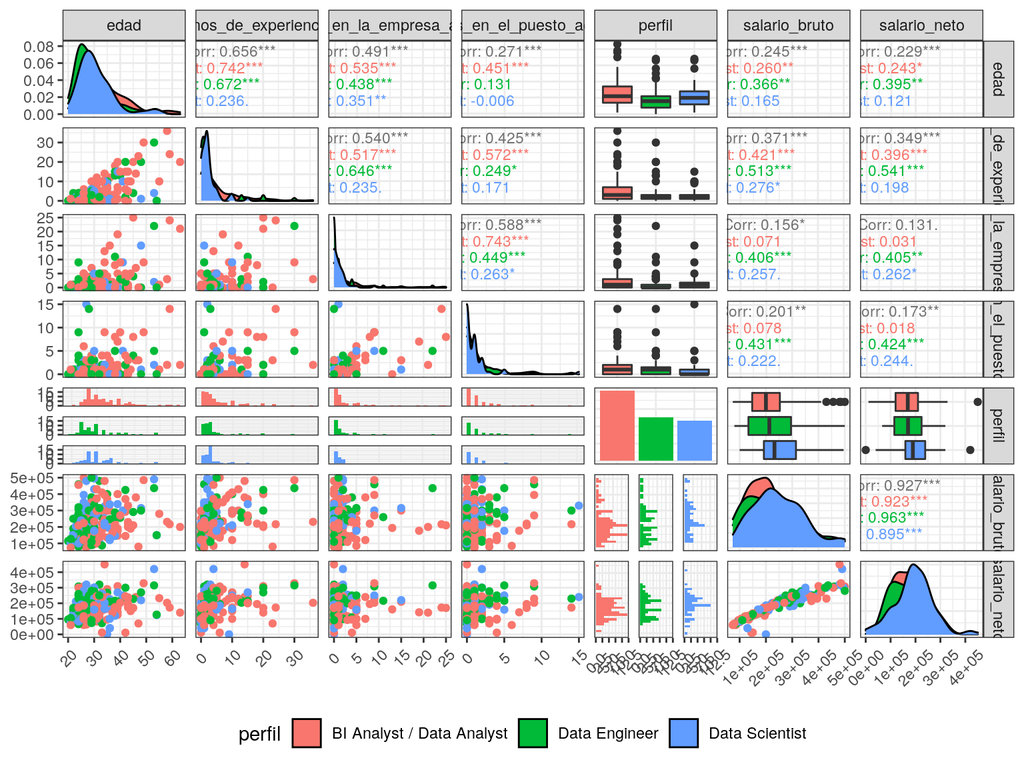

```r
encuesta_ds_final %>%
  ggpairs(aes(color=perfil),upper = list(continuous = wrap("cor", size = 3, hjust=0.8, alignPercent=0.15)), legend = 25) +
  theme_bw() +
  theme(axis.text.x = element_text(angle=45, vjust=0.5), legend.position = "bottom")
```

Ahora, respecto de nuestra variable a predecir, el **salario bruto**, observamos:

- Existe una correlación positiva moderada con la edad y los años de experiencia.
- Existe una correlación positiva baja con los años en la empresa y los años en el puesto. En ambas variables existe una diferencia en la correlación entre los perfiles.

Al igual que antes podemos observar como luce la correlación de Spearman para el dataset final

```r
encuesta_ds_final %>%
  select_if(is.numeric) %>% # selecciona las variables numericas
  correlate(method = 'spearman') %>% # convierte la matriz de corr en dataframe
  shave() %>% # solo muestra información debajo de la diagonal principal
  fashion(decimals = 3) # acomoda los datos en forma tidy (por ej. redondeo de decimales)
```

| term | edad | anos_de_experiencia | anos_en_la_empresa_actual | anos_en_el_puesto_actual | salario_bruto | salario_neto |
| --- | --- | --- | --- | --- | --- | --- |
| edad |  |  |  |  |  |  |
| anos_de_experiencia | .475 |  |  |  |  |  |
| anos_en_la_empresa_actual | .276 | .515 |  |  |  |  |
| anos_en_el_puesto_actual | .219 | .525 | .765 |  |  |  |
| salario_bruto | .304 | .529 | .254 | .220 |  |  |
| salario_neto | .266 | .491 | .235 | .210 | .969 |  |

Si bien siguen existiendo algunas diferencias, no son tan marcadas debido a la eliminación de los outliers univariados.

## Correlación

Habiendo realizado la limpieza previa construimos la matriz de correlación de nuestras variables. Vamos a utilizar el método de Pearson.

```r
# calculo matriz de correlacion para los registros completos (omitiendo faltantes) para variables numéricas con ambos métodos
# pearson
matriz.correl.pe <- encuesta_ds_final %>%
  select_if(is.numeric) %>% # Seleccionamos las variables numéricas
 correlate(use = "complete.obs", method = "pearson") %>%
  shave() %>%
  fashion()
matriz.correl.pe
```

| term | edad | anos_de_experiencia | anos_en_la_empresa_actual | anos_en_el_puesto_actual | salario_bruto | salario_neto |
| --- | --- | --- | --- | --- | --- | --- |
| edad |  |  |  |  |  |  |
| anos_de_experiencia | .66 |  |  |  |  |  |
| anos_en_la_empresa_actual | .49 | .54 |  |  |  |  |
| anos_en_el_puesto_actual | .27 | .43 | .59 |  |  |  |
| salario_bruto | .25 | .37 | .16 | .20 |  |  |
| salario_neto | .23 | .35 | .13 | .17 | .93 |  |

Como ya vimos en la sección inmediatamente anterior, nuestra variable de interés (el **salario_bruto**) tiene una correlación positiva (método de Pearson) MODERADA con las variables de **edad**: 0.25 y **años de experiencia**: 0.37 y BAJA con los **años en la empresa actual**: 0.16 y los **años en el puesto actual**: 0.20.

La edad y los años de experiencia parecen ser buenas variables para predecir el salario bruto de acuerdo al modelo planteado.

## Modelo Lineal Simple[^1]

Recordemos que nuestro modelo es un modelo es un modelo lineal simple propone que la relación entre X e Y es:

$$Y = \beta_0 + \beta_1X + \epsilon$$
donde $\epsilon$ es el término del error inobservable, $\beta_0$ y $\beta_1$ son constantes desconocidas que se denominan parámetros del modelo, o coeficientes de la ecuación. El modelo se denomina lineal pues propone que la Y depende linealmente de X.

El modelo en términos de la esperanza de Y condicional a las X’s que notaremos E(Y|X):

$$E(Y|X) = \beta_0 + \beta_1X$$
Se la suele llamar función de respuesta y es una recta.

### Modelos

Recordemos que nuestro modelo elegido para explicar el salario bruto es:

$salarioBruto = \beta_0 +\beta_1x+\epsilon$

Existen numerosos modelos que sostienen que existe una relación positiva entre la edad o años de experiencia laboral y el salario de una persona. Estos modelos suponen que la edad o años de experiencia laboral son variables que miden de manera indirecta la experiencia laboral de una persona. Entonces, a mayor experiencia (edad/años experiencia laboral) debería corresponder una mayor remuneración de la fuerza de trabajo.

### Modelo Edad

Comencemos planteando un modelo lineal con la edad como variable independiente:

$salarioBruto = \beta_0 +\beta_1Edad+\epsilon$

Para ajustar un modelo lineal simple, es decir, estimar los valores usamos la función con los siguientes argumentos de la función: `lm(formula = y ~ x, data = dataset)`

```r
# Crear el modelo lineal de la edad
modelo_edad = lm(formula = salario_bruto ~ edad, data = encuesta_ds_final)
# Observamos que devuelve el modelo
modelo_edad
```

```
##
## Call:
## lm(formula = salario_bruto ~ edad, data = encuesta_ds_final)
##
## Coefficients:
## (Intercept)         edad
##      127646         3218
```

El modelo nos muestra la llamada utilizada y los valores de los coeficientes estimados: $\hat{\beta_0} =127646$ y $\hat{\beta_1} = 3218$.

#### Interpretación de los coeficientes estimados

Un modelo generado con la función `lm()` es un objeto que tiene muchos atributos a los cuales se puede acceder con el simbolo $. En este caso, nos interesa traer los coeficientes estimados.

```r
modelo_edad$coefficients
```

```
## (Intercept)        edad
##  127645.906    3217.943
```

- Teóricamente el valor $\hat{\beta_0} = 127645.91$ es el salario bruto **esperado** para una persona recién nacida (0 años). Por este motivo este valor carece de interpretación práctica.
- El valor de $\hat{\beta_1}$ indica que por cada aumento de un año de edad el salario bruto **esperado** aumenta en 3217.94 pesos

#### Gráfico del modelo

Procedemos a graficar nuestro modelo accediendo a la información de los coeficientes estimados.

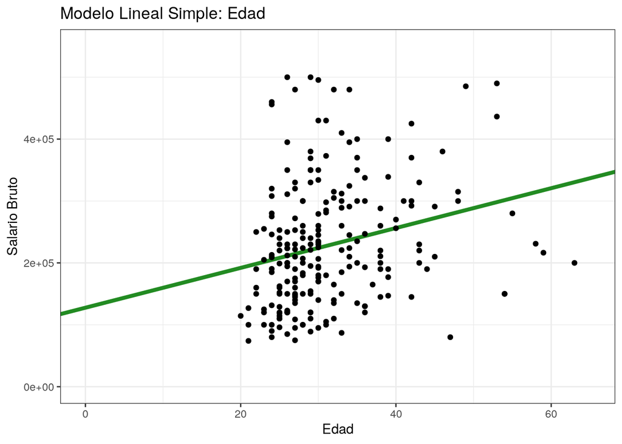

```r
# Accedemos a la información de los coeficientes estimados
intercepto = modelo_edad$coefficients[1]
pendiente = modelo_edad$coefficients[2]

# Graficamos el dataset y el modelo
encuesta_ds_final %>% ggplot(., aes(x = edad, y = salario_bruto)) +
  geom_abline(intercept = intercepto, slope = pendiente, color="forestgreen", size=1.5) + # capa del modelo
  geom_point() + #capa de los datos
  theme_bw() +
  scale_x_continuous(limits = c(0,65)) +
  scale_y_continuous(limits = c(0,550000)) +
  labs(title="Modelo Lineal Simple: Edad", x="Edad", y="Salario Bruto")
```

### Modelo Años de experiencia

Ahora realicemos un modelo con los años de experiencia como variable independiente:

$salarioBruto = \beta_0 +\beta_1AñosExperiencia+\epsilon$

```r
# Crear el modelo lineal de los años de experiencia
modelo_experiencia = lm(formula = salario_bruto ~ anos_de_experiencia, data = encuesta_ds_final)
```

#### Interpretación de los coeficientes estimados

```r
coeficientes_experiencia = modelo_experiencia$coefficients
coeficientes_experiencia
```

```
##         (Intercept) anos_de_experiencia
##          202389.926            6405.658
```

- El valor de $\hat{\beta_0}$ indica que el salario bruto **esperado** es de $ 202389.93 para una persona con perfil de Data Scientist, Data Engineer o Data Analyst sin experiencia laboral.
- El valor de $\hat{\beta_1}$ indica que por cada aumento de un año de experiencia el salario bruto **esperado** aumenta en $6405.66.

#### Gráfico del modelo

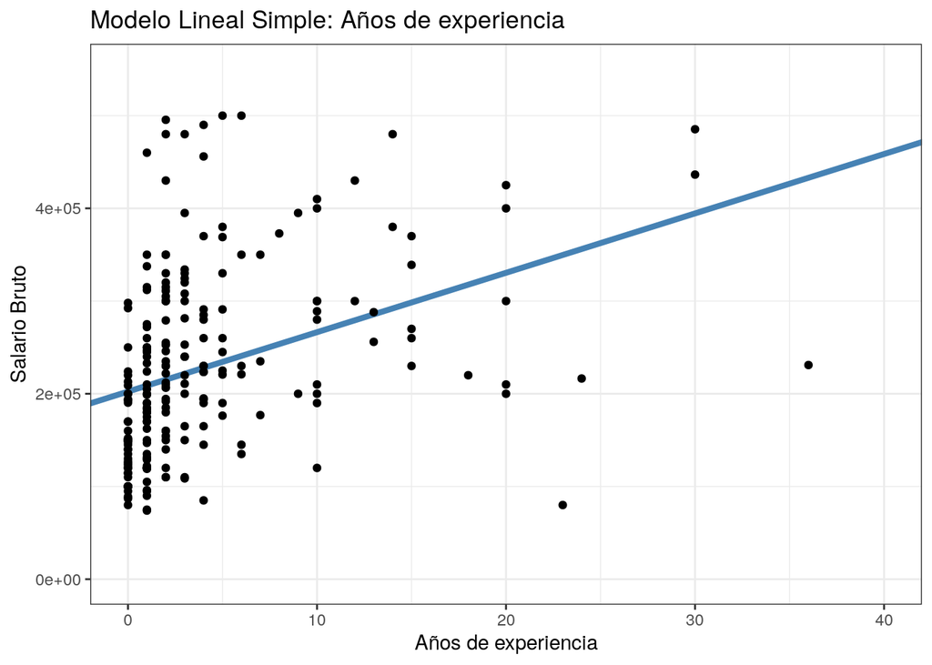

```r
# Accedemos a la información de los coeficientes estimados
intercepto = modelo_experiencia$coefficients[1]
pendiente = modelo_experiencia$coefficients[2]

# Graficamos el dataset y el modelo
encuesta_ds_final %>% ggplot(., aes(x = anos_de_experiencia, y = salario_bruto)) +
  geom_abline(intercept = intercepto, slope = pendiente, color="steelblue", size=1.5) + # capa del modelo
  geom_point() + #capa de los datos
  theme_bw() +
  scale_x_continuous(limits = c(0,40)) +
  scale_y_continuous(limits = c(0,550000)) +
  labs(title="Modelo Lineal Simple: Años de experiencia", x="Años de experiencia", y="Salario Bruto")
```

### Modelo años en la empresa actual

Por último realizamos un modelo con los años de experiencia en la empresa actual como variable independiente:

$salarioBruto = \beta_0 +\beta_1AñosEmpresa+\epsilon$

```r
# Crear el modelo lineal de los años de experiencia
modelo_empresa = lm(formula = salario_bruto ~ anos_en_la_empresa_actual, data = encuesta_ds_final)
```

#### Interpretación de los coeficientes estimados

```r
coeficientes_empresa = modelo_empresa$coefficients
coeficientes_empresa
```

```
##               (Intercept) anos_en_la_empresa_actual
##                220546.945                  3941.442
```

- El valor de $\hat{\beta_0}$ indica que el salario bruto **esperado** es de $220546.95 para una persona con perfil de Data Scientist/Engineer o Data Analyst que recién comienza en una empresa.
- El valor de $\hat{\beta_1}$ indica que por cada aumento de un año de experiencia en la misma empresa el salario bruto **esperado** aumenta en $3941.44.

#### Gráfico del modelo

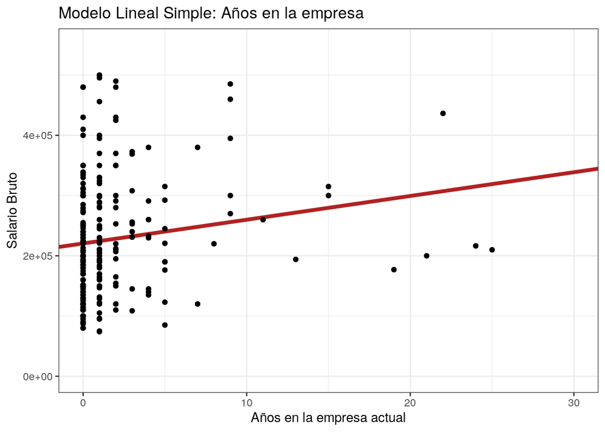

```r
# Accedemos a la información de los coeficientes estimados
intercepto = modelo_empresa$coefficients[1]
pendiente = modelo_empresa$coefficients[2]

# Graficamos el dataset y el modelo
encuesta_ds_final %>% ggplot(., aes(x = anos_en_la_empresa_actual, y = salario_bruto)) +
  geom_abline(intercept = intercepto, slope = pendiente, color="firebrick", size=1.5) + # capa del modelo
  geom_point() + #capa de los datos
  theme_bw() +
  scale_x_continuous(limits = c(0,30)) +
  scale_y_continuous(limits = c(0,550000)) +
  labs(title="Modelo Lineal Simple: Años en la empresa ", x="Años en la empresa actual", y="Salario Bruto")
```

[^1]: Fuente: Apunte de Regresión Lineal - María Eugenia Szretter Noste